# MG205: Econometrics Theory and Applications

Empirical Exercise 7: Revolving Door Lobbyists

José Ignacio González Rojas

j.i.gonzalez-rojas@lse.ac.uk

London School of Economics and Political Science

## Today: Quantifying the Revolving Door Premium

### From Cross-Section to Within-Person Variation

#### Today’s Roadmap

1. The revolving door industry
2. Identification from politician exits
3. Revenue premium and event study
4. Committee heterogeneity as falsification

#### Building on T8

- **Panel FE** removes time-invariant heterogeneity
- **Today:** politician exits provide **within-person** variation in connections
- **Outcome:** quantify the causal revenue premium of political access

## Lobbyists Convert Political Access into Revenue

### The Lobbying Industry

The **revolving door** describes the movement of personnel from government service into private lobbying (Blanes i Vidal et al., 2012).

#### Connections Theory

Revolving-door lobbyists profit from **political access:**

- Direct access to former colleagues
- Informal networks and trust
- Signal of influence to clients

#### Expertise Theory

Lobbyists also provide **regulatory knowledge:**

- Understanding of legislative processes
- Specialised knowledge of policy areas
- Human capital from government service

## Connections and Expertise Are Confounded in Cross-Section

### The Identification Challenge

$$\log(\text{revenue})_{i} = \beta_{0} + \beta_{1} \cdot \text{connections}_{i} + \underbrace{\beta_{2} \cdot \text{expertise}_{i} + \beta_{3} \cdot \text{ability}_{i}}_{\text{(unobserved)}} + e_{i}$$

- OLS cannot identify $\beta_{1}$ alone: $\hat{\beta}_{1}^{\text{OLS}}$ picks up $\beta_{1} + \text{bias}$
- Cross-sectional comparison confounds connections with expertise and ability **(both unobserved)**
- Need variation in connections **holding the lobbyist fixed**

## Politician Exits Provide Exogenous Variation in Connections

### The Empirical Strategy

When a senator or representative exits Congress:

- $\text{connections}_{it}$ **drops** — one fewer currently-serving ex-boss
- **Expertise and ability remain constant** — the lobbyist is unchanged

#### What does “remain constant” assume?

- **Lobbyist FE ($\alpha_{i}$)** absorbs time-invariant characteristics: expertise, ability, career capital
- **Experience controls (quadratic)** absorb learning-by-doing
- **Robustness:** individual-specific time trends, firm FE

The exit is a within-person shock that separates $\beta$ from unobserved ability

# Data and Measurement

## Revolving Door Lobbyists Earn Most of the Industry’s Revenue

### Blanes i Vidal et al. (2012), Table 1

- **Revolving door:** 41.6% of all lobbyists previously held government positions
- **Ex-staffers:** 22.6% are former congressional staffers — the subsample used for causal identification
- **Revenue concentration:** revolving-door lobbyists account for 56% of total industry revenue despite being a minority

The concentration of revenue among connected lobbyists suggests connections — not just expertise — command a premium.

## Revolving Door Lobbyists Capture Disproportionate Revenue

### Revenue Distribution

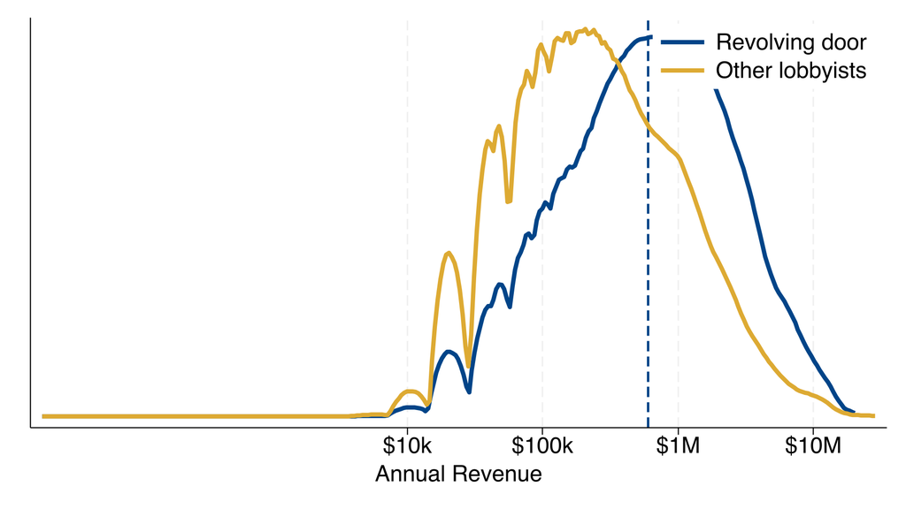

- Revolving-door lobbyists cluster higher on the revenue distribution
- The gap between distributions is economically large
- At the median, revolving-door lobbyists earn roughly twice as much
- A coefficient of 0.24 in log-revenue means a **24% change**

## Ex-Staffers Panel: 1,113 Lobbyists Over 22 Semesters

### Sample Overview

- **n:** 10,418 lobbyist-semester observations
- **Unit of observation:** lobbyist $\times$ semester
- **Period:** 1998–2008 (22 semesters)
- **Data sources:** LDA filings merged with Biographical Directory of the US Congress

Should we be worried that we only consider ex-staffers?

# Identification Strategy

## An “Ever Connected” Dummy Cannot Be Identified with Fixed Effects

### Why We Need Time-Varying Measures

**Step 1 — Without FE:** Regress $\log(\text{revenue})_{it}$ on $\mathbb{1}[\text{ever connected}_{i}]$ — significant, but captures cross-sectional differences only.

**Step 2 — Add lobbyist FE:** $\mathbb{1}[\text{ever connected}_{i}]$ is **dropped**. It equals 1 in every period, so it is collinear with $\alpha_{i}$.

**Step 3 — Use time-varying connections:** $\text{connections}_{it}$ (count: 0, 1, 2, …) **does** change when a politician exits. FE can identify $\beta$ because there is within-lobbyist variation.

## Politician Exits Are Plausibly Exogenous

### Exit Reasons

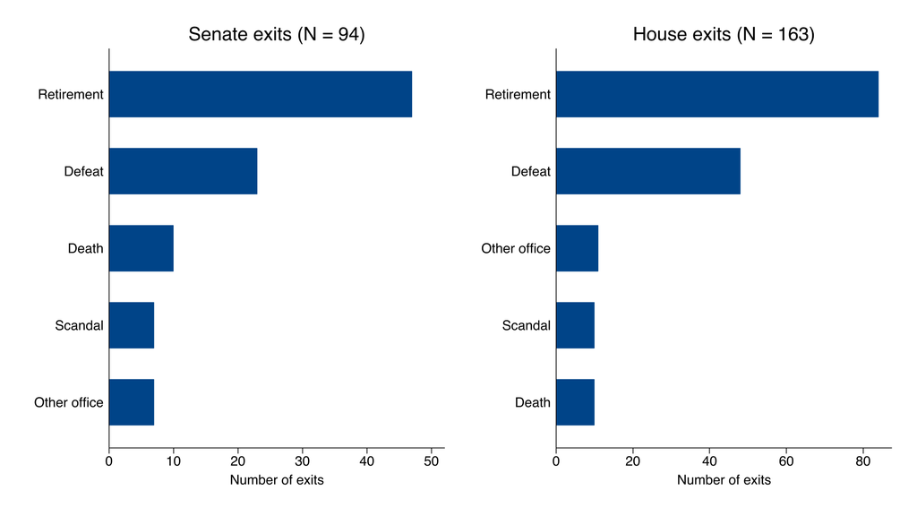

## The Full Specification Controls for Party-Chamber Trends

### Panel Data Model

$$\log(\text{revenue})_{it} = \alpha_{i} + \beta \cdot \text{connections}_{it} + f(\text{experience}_{it}) + \gamma_{t}^{\text{pc}} + e_{it}$$

| Component | Definition |
| --- | --- |
| $\alpha_{i}$ | Lobbyist FE — absorbs expertise, ability, career capital |
| $\text{connections}_{it}$ | Count of currently serving ex-bosses (0, 1, 2, …) |
| $f(\text{experience}_{it})$ | Quadratic in lobbyist experience (captures career progression) |
| $\gamma_{t}^{\text{pc}}$ | Party $\times$ chamber $\times$ semester FE (partisan demand shocks) |
| $e_{it}$ | Idiosyncratic error |

## Losing a Senate Connection Reduces Revenue by 24%

### Main Results

| Variable | Coefficient | SE |
| --- | --- | --- |
| **Number of senators** | 0.24*** | (0.07) |
| Number of representatives | 0.10* | (0.05) |
| Individual FE: Yes \| Party-chamber-time FE: Yes \| Experience: Yes |  |  |
| N = 10,418 \| Individuals = 1,113 |  |  |

Note: Dependent variable is log(revenue). SE in parentheses. *** p<0.01, * p<0.10.

- **Senate:** 0.24*** — at median revenue, worth ~$182k/year per connection
- **House:** 0.10* — senators are fewer and individually more powerful, hence scarcer connections

## Revenue Drops Sharply and Persistently After Exit

### Event-Study Evidence

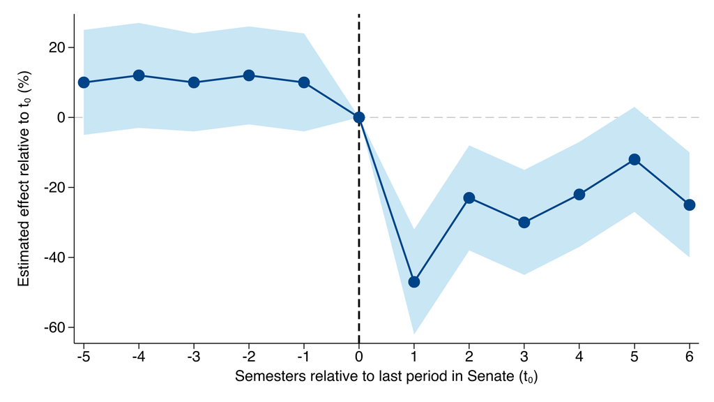

- $t_{0}$ (last semester in Senate) normalised to zero: all coefficients relative to $t_{0}$
- **No pre-trends:** flat coefficients before exit validate parallel trends
- **Sharp drop at $t_{0} + 1$:** revenue falls immediately after politician exits
- **~20–25% persistent decline:** connection value does not recover

Connection value is immediate and durable — not an expertise story

## Powerful Committee Connections Generate the Largest Premiums

### Committee Heterogeneity as Falsification

| Variable | Coefficient | SE |
| --- | --- | --- |
| Senate |  |  |
| **Finance** | 0.36*** | (0.09) |
| **Appropriations** | 0.45*** | (0.15) |
| Neither | −0.11 | (0.12) |
| House |  |  |
| **Ways & Means** | 0.35*** | (0.10) |
| Appropriations | 0.06 | (0.11) |
| Neither | 0.03 | (0.06) |
| Individual FE: Yes \| Party-chamber-time FE: Yes \| Experience: Yes |  |  |

Note: Dependent variable is log(revenue). SE in parentheses. *** p<0.01.

## Connection Loss Drives Some Lobbyists Out of the Industry

### Participation Effects

A Senate exit increases the probability of **leaving the lobbying industry** by **27 percentage points**.

The revenue estimates are a **lower bound** on the true connection premium:

- Lobbyists who lose connections and exit are the weakest earners
- Their attrition means we observe only those who remain — survivorship selects for lobbyists with alternative revenue sources
- The causal effect of connections on revenue may be larger than 24%

Attrition of the weakest earners biases the revenue estimate toward zero

# Implications

## Connections Are Valuable, Perishable, and Committee-Specific

### Mechanisms

1. **Access** — ability to obtain meetings with decision-makers
2. **Network** — information flow through social ties and trust
3. **Information** — knowledge of the legislative process and timing
4. **Signalling** — clients pay for perceived influence

#### What the evidence rules out

- **Event study** rules out expertise: revenue drops **immediately** at exit, not gradually
- **Committee heterogeneity** rules out seniority: no premium without committee power

Access to political power, not knowledge, drives the revolving-door premium

## Cooling-Off Periods Would Reduce the Revolving Door Premium

### Policy Implications

1. **Cooling-off periods** — delay monetisation of connections; the premium shrinks if ex-staffers cannot lobby for two years
2. **Mandatory disclosure** — clients and regulators can identify revolving-door lobbyists and evaluate their claims
3. **Higher staff salaries** — improving the outside option reduces incentives to leverage connections commercially

## Three Lessons from the Revolving Door

### Summary

1. **Fixed effects separate connections from expertise**  
   The FE trap forces identification from within-lobbyist changes only
2. **Senate connections carry a 24% revenue premium**  
   Immediate, causal, and larger than House — senate power is scarcer
3. **Effects are immediate, persistent, and scale with committee power**  
   Event study and heterogeneity results confirm the access mechanism

## Next Week: Donohue and Wolfers Challenge the Deterrence Claim

### Preview

EE8 examines whether the death penalty deters crime.

- **Dezhbakhsh et al. (2003):** claim large deterrent effects using IV on US state panel data
- **Donohue & Wolfers (2005):** show that small specification changes — different time periods, functional forms, or control variables — **reverse the sign** of the estimated effect

Same data, same methods, opposite conclusions.

# References

## References

Blanes i Vidal, J., Draca, M., & Fons-Rosen, C. (2012). Revolving Door Lobbyists. *American Economic Review*, *102*(7), 3731–3748. https://doi.org/10.1257/aer.102.7.3731

Dezhbakhsh, H., Rubin, P. H., & Shepherd, J. M. (2003). Does Capital Punishment Have a Deterrent Effect? New Evidence from Postmoratorium Panel Data. *American Law and Economics Review*, *5*(2), 344–376. https://doi.org/10.1093/aler/ahg021

Donohue, J. J., & Wolfers, J. (2005). Uses and Abuses of Empirical Evidence in the Death Penalty Debate. *Stanford Law Review*, *58*(3), 791–845.